# Quantium Virtual Internship - Retail Strategy and Analytics - Task 1

```python
# Loading required libraries
import numpy as np
import matplotlib.pyplot as plt
import pandas as pd
import datetime
```

```python
Purchasedata = pd.read_csv(r"C:\Users\odeda\Downloads\QVI_purchase_behaviour.csv")

transactiondata = pd.read_excel(r"C:\Users\odeda\Downloads\QVI_transaction_data-.xlsx")
```

# Exploratory Data Analysis

First, we want to examine the data and make sure that it is in a usable form for our analysis.

```python
# view a summary of the table
trans_df = transactiondata.copy() # Keep a copy for a quick reset
trans_df
```

|  | DATE | STORE_NBR | LYLTY_CARD_NBR | TXN_ID | PROD_NBR | PROD_NAME | PROD_QTY | TOT_SALES |
| --- | --- | --- | --- | --- | --- | --- | --- | --- |
| 0 | 43390 | 1 | 1000 | 1 | 5 | Natural Chip Compny SeaSalt175g | 2 | 6.0 |
| 1 | 43599 | 1 | 1307 | 348 | 66 | CCs Nacho Cheese 175g | 3 | 6.3 |
| 2 | 43605 | 1 | 1343 | 383 | 61 | Smiths Crinkle Cut Chips Chicken 170g | 2 | 2.9 |
| 3 | 43329 | 2 | 2373 | 974 | 69 | Smiths Chip Thinly S/Cream&Onion 175g | 5 | 15.0 |
| 4 | 43330 | 2 | 2426 | 1038 | 108 | Kettle Tortilla ChpsHny&Jlpno Chili 150g | 3 | 13.8 |
| ... | ... | ... | ... | ... | ... | ... | ... | ... |
| 264831 | 43533 | 272 | 272319 | 270088 | 89 | Kettle Sweet Chilli And Sour Cream 175g | 2 | 10.8 |
| 264832 | 43325 | 272 | 272358 | 270154 | 74 | Tostitos Splash Of Lime 175g | 1 | 4.4 |
| 264833 | 43410 | 272 | 272379 | 270187 | 51 | Doritos Mexicana 170g | 2 | 8.8 |
| 264834 | 43461 | 272 | 272379 | 270188 | 42 | Doritos Corn Chip Mexican Jalapeno 150g | 2 | 7.8 |
| 264835 | 43365 | 272 | 272380 | 270189 | 74 | Tostitos Splash Of Lime 175g | 2 | 8.8 |

264836 rows × 8 columns

We can see that the date is in an integer format; change to DD/MM/YYYY format.

```python
# Change date from xls integer dates to date format in customer data
trans_df['DATE'] = pd.to_datetime(trans_df['DATE'], unit='D', origin='1899-12-30')
print(trans_df['DATE'].dtype) # check format of replacement date column
```

```
datetime64[ns]
```

Then we want to ensure that we are only examining chip purchases.

```python
# View all unique entries in the product name column
trans_df['PROD_NAME'].unique()
```

```
array(['Natural Chip        Compny SeaSalt175g',
       'CCs Nacho Cheese    175g',
       'Smiths Crinkle Cut  Chips Chicken 170g',
       'Smiths Chip Thinly  S/Cream&Onion 175g',
       'Kettle Tortilla ChpsHny&Jlpno Chili 150g',
       'Old El Paso Salsa   Dip Tomato Mild 300g',
       'Smiths Crinkle Chips Salt & Vinegar 330g',
       'Grain Waves         Sweet Chilli 210g',
       'Doritos Corn Chip Mexican Jalapeno 150g',
       'Grain Waves Sour    Cream&Chives 210G',
       'Kettle Sensations   Siracha Lime 150g',
       'Twisties Cheese     270g', 'WW Crinkle Cut      Chicken 175g',
       'Thins Chips Light&  Tangy 175g', 'CCs Original 175g',
       'Burger Rings 220g', 'NCC Sour Cream &    Garden Chives 175g',
       'Doritos Corn Chip Southern Chicken 150g',
       'Cheezels Cheese Box 125g', 'Smiths Crinkle      Original 330g',
       'Infzns Crn Crnchers Tangy Gcamole 110g',
       'Kettle Sea Salt     And Vinegar 175g',
       'Smiths Chip Thinly  Cut Original 175g', 'Kettle Original 175g',
       'Red Rock Deli Thai  Chilli&Lime 150g',
       'Pringles Sthrn FriedChicken 134g', 'Pringles Sweet&Spcy BBQ 134g',
       'Red Rock Deli SR    Salsa & Mzzrlla 150g',
       'Thins Chips         Originl saltd 175g',
       'Red Rock Deli Sp    Salt & Truffle 150G',
       'Smiths Thinly       Swt Chli&S/Cream175G', 'Kettle Chilli 175g',
       'Doritos Mexicana    170g',
       'Smiths Crinkle Cut  French OnionDip 150g',
       'Natural ChipCo      Hony Soy Chckn175g',
       'Dorito Corn Chp     Supreme 380g', 'Twisties Chicken270g',
       'Smiths Thinly Cut   Roast Chicken 175g',
       'Smiths Crinkle Cut  Tomato Salsa 150g',
       'Kettle Mozzarella   Basil & Pesto 175g',
       'Infuzions Thai SweetChili PotatoMix 110g',
       'Kettle Sensations   Camembert & Fig 150g',
       'Smith Crinkle Cut   Mac N Cheese 150g',
       'Kettle Honey Soy    Chicken 175g',
       'Thins Chips Seasonedchicken 175g',
       'Smiths Crinkle Cut  Salt & Vinegar 170g',
       'Infuzions BBQ Rib   Prawn Crackers 110g',
       'GrnWves Plus Btroot & Chilli Jam 180g',
```

[output cut: 42 more lines]

```
       'Infuzions SourCream&Herbs Veg Strws 110g',
       'Kettle Tortilla ChpsFeta&Garlic 150g',
       'Infuzions Mango     Chutny Papadums 70g',
       'RRD Steak &         Chimuchurri 150g',
       'RRD Honey Soy       Chicken 165g',
       'Sunbites Whlegrn    Crisps Frch/Onin 90g',
       'RRD Salt & Vinegar  165g', 'Doritos Cheese      Supreme 330g',
       'Smiths Crinkle Cut  Snag&Sauce 150g',
       'WW Sour Cream &OnionStacked Chips 160g',
       'RRD Lime & Pepper   165g',
       'Natural ChipCo Sea  Salt & Vinegr 175g',
       'Red Rock Deli Chikn&Garlic Aioli 150g',
       'RRD SR Slow Rst     Pork Belly 150g', 'RRD Pc Sea Salt     165g',
       'Smith Crinkle Cut   Bolognese 150g', 'Doritos Salsa Mild  300g'],
      dtype=object)
```

While it looks like we have chips, we want to check that the products are only chips by counting the word frequencies in the product names. To make this process clearer, we can remove the digits and symbols from the names.

```python
# Remove digits from the product names
prod_name = trans_df['PROD_NAME'].str.replace(r'[0-9]+[gG]','');

# Remove & characters from the product names and replace with a space to separate flavours
prod_name = prod_name.str.replace(r'&',' ');
```

```python
# Count the frequencies of words in product names and display counts in descending order
word_counts = pd.Series(' '.join(prod_name).split()).value_counts()

with pd.option_context('display.max_rows', None): # show all rows
  display(word_counts)
```

```
Chips              49770
Kettle             41288
Smiths             28860
Salt               27976
Cheese             27890
Pringles           25102
Doritos            24962
Crinkle            23960
Corn               22063
Original           21560
Cut                20754
Chip               18645
Chicken            18577
Salsa              18094
Chilli             15390
Sea                14145
Thins              14075
Sour               13882
Crisps             12607
Vinegar            12402
RRD                11894
Sweet              11060
Infuzions          11057
Supreme            10963
Chives             10951
Cream              10723
WW                 10320
Cobs                9693
Popd                9693
Tortilla            9580
Tostitos            9471
Twisties            9454
BBQ                 9434
Sensations          9429
Lime                9347
Dip                 9324
Old                 9324
Paso                9324
El                  9324
Tomato              7669
```

[output cut: 142 more lines]

```
Puffs               1448
saltd               1441
Originl             1441
CutSalt/Vinegr      1440
OnionDip            1438
Aioli               1434
Chikn               1434
Sunbites            1432
Frch/Onin           1432
Whlegrn             1432
Pc                  1431
Garden              1419
NCC                 1419
Fries               1418
dtype: int64
```

```python
# Remove salsas from the dataset
trans_df = trans_df[trans_df['PROD_NAME'].str.contains(r"[Ss]alsa") == False]
trans_df.shape # check for a reduction in no of rows
```

```
(246742, 8)
```

Now we can create summaries of the data (eg min, max, mean) to see if there are any obvious outliers in the data and if there are any nulls in any of the columns.

```python
# Create summaries of the transaction data
trans_df.describe()
```

|  | STORE_NBR | LYLTY_CARD_NBR | TXN_ID | PROD_NBR | PROD_QTY | TOT_SALES |
| --- | --- | --- | --- | --- | --- | --- |
| count | 246742.000000 | 2.467420e+05 | 2.467420e+05 | 246742.000000 | 246742.000000 | 246742.000000 |
| mean | 135.051098 | 1.355310e+05 | 1.351311e+05 | 56.351789 | 1.908062 | 7.321322 |
| std | 76.787096 | 8.071528e+04 | 7.814772e+04 | 33.695428 | 0.659831 | 3.077828 |
| min | 1.000000 | 1.000000e+03 | 1.000000e+00 | 1.000000 | 1.000000 | 1.700000 |
| 25% | 70.000000 | 7.001500e+04 | 6.756925e+04 | 26.000000 | 2.000000 | 5.800000 |
| 50% | 130.000000 | 1.303670e+05 | 1.351830e+05 | 53.000000 | 2.000000 | 7.400000 |
| 75% | 203.000000 | 2.030840e+05 | 2.026538e+05 | 87.000000 | 2.000000 | 8.800000 |
| max | 272.000000 | 2.373711e+06 | 2.415841e+06 | 114.000000 | 200.000000 | 650.000000 |

```python
# Check if there are any nans in the dataset
trans_df.isnull().values.any()
```

```
False
```

From the summary, there is at least one transaction with 200 packets. Let's investigate this purchase further.

```python
# Filter the entries that have 200 packets.
trans_df.loc[trans_df['PROD_QTY'] == 200.0]
```

|  | DATE | STORE_NBR | LYLTY_CARD_NBR | TXN_ID | PROD_NBR | PROD_NAME | PROD_QTY | TOT_SALES |
| --- | --- | --- | --- | --- | --- | --- | --- | --- |
| 69762 | 2018-08-19 | 226 | 226000 | 226201 | 4 | Dorito Corn Chp Supreme 380g | 200 | 650.0 |
| 69763 | 2019-05-20 | 226 | 226000 | 226210 | 4 | Dorito Corn Chp Supreme 380g | 200 | 650.0 |

The same customer has made these transactions. They could have been for commercial purposes so we can check to see if they made any other purchases.

```python
# Filter the entires by the customer
trans_df.loc[trans_df['LYLTY_CARD_NBR'] == 226000]
```

|  | DATE | STORE_NBR | LYLTY_CARD_NBR | TXN_ID | PROD_NBR | PROD_NAME | PROD_QTY | TOT_SALES |
| --- | --- | --- | --- | --- | --- | --- | --- | --- |
| 69762 | 2018-08-19 | 226 | 226000 | 226201 | 4 | Dorito Corn Chp Supreme 380g | 200 | 650.0 |
| 69763 | 2019-05-20 | 226 | 226000 | 226210 | 4 | Dorito Corn Chp Supreme 380g | 200 | 650.0 |

```python
# Remove the transactions
trans_df = trans_df[trans_df['LYLTY_CARD_NBR'] != 226000]
trans_df.shape # check for a reduction of 2 rows (i.e. 246740 rows)
```

```
(246740, 8)
```

```python
# Recheck the data summary
trans_df.describe()
```

|  | STORE_NBR | LYLTY_CARD_NBR | TXN_ID | PROD_NBR | PROD_QTY | TOT_SALES |
| --- | --- | --- | --- | --- | --- | --- |
| count | 246740.000000 | 2.467400e+05 | 2.467400e+05 | 246740.000000 | 246740.000000 | 246740.000000 |
| mean | 135.050361 | 1.355303e+05 | 1.351304e+05 | 56.352213 | 1.906456 | 7.316113 |
| std | 76.786971 | 8.071520e+04 | 7.814760e+04 | 33.695235 | 0.342499 | 2.474897 |
| min | 1.000000 | 1.000000e+03 | 1.000000e+00 | 1.000000 | 1.000000 | 1.700000 |
| 25% | 70.000000 | 7.001500e+04 | 6.756875e+04 | 26.000000 | 2.000000 | 5.800000 |
| 50% | 130.000000 | 1.303670e+05 | 1.351815e+05 | 53.000000 | 2.000000 | 7.400000 |
| 75% | 203.000000 | 2.030832e+05 | 2.026522e+05 | 87.000000 | 2.000000 | 8.800000 |
| max | 272.000000 | 2.373711e+06 | 2.415841e+06 | 114.000000 | 5.000000 | 29.500000 |

Now look at the number of transaction lines over time to see if there are any obvious data issues such as missing data from particular days.

```python
# Count transactions by date to see if there are any missing days
count = trans_df.groupby(trans_df['DATE'].dt.date).size().reset_index(name = 'COUNT')
count.shape
```

```
(364, 2)
```

```python
# There is one day of data missing. First check the range of dates by sorting in time order.
trans_df.sort_values(by='DATE')
```

|  | DATE | STORE_NBR | LYLTY_CARD_NBR | TXN_ID | PROD_NBR | PROD_NAME | PROD_QTY | TOT_SALES |
| --- | --- | --- | --- | --- | --- | --- | --- | --- |
| 9161 | 2018-07-01 | 88 | 88140 | 86914 | 25 | Pringles SourCream Onion 134g | 2 | 7.4 |
| 155442 | 2018-07-01 | 60 | 60276 | 57330 | 3 | Kettle Sensations Camembert & Fig 150g | 2 | 9.2 |
| 181349 | 2018-07-01 | 199 | 199014 | 197623 | 104 | Infuzions Thai SweetChili PotatoMix 110g | 2 | 7.6 |
| 229948 | 2018-07-01 | 35 | 35052 | 31630 | 11 | RRD Pc Sea Salt 165g | 1 | 3.0 |
| 104647 | 2018-07-01 | 72 | 72104 | 71038 | 20 | Doritos Cheese Supreme 330g | 2 | 11.4 |
| ... | ... | ... | ... | ... | ... | ... | ... | ... |
| 10254 | 2019-06-30 | 112 | 112141 | 114611 | 98 | NCC Sour Cream & Garden Chives 175g | 2 | 6.0 |
| 113220 | 2019-06-30 | 207 | 207155 | 205513 | 99 | Pringles Sthrn FriedChicken 134g | 2 | 7.4 |
| 229182 | 2019-06-30 | 10 | 10140 | 9882 | 12 | Natural Chip Co Tmato Hrb&Spce 175g | 2 | 6.0 |
| 229015 | 2019-06-30 | 6 | 6258 | 6047 | 29 | French Fries Potato Chips 175g | 1 | 3.0 |
| 262768 | 2019-06-30 | 183 | 183196 | 185975 | 22 | Thins Chips Originl saltd 175g | 2 | 6.6 |

246740 rows × 8 columns

We can see that the dates range from 1 Jul 2018 to 30 Jun 2019. Now we want to check through the year of dates to see which day the data is missing.

```python
# Generate a list of dates with transactions in ascending order
date_counts = trans_df.groupby('DATE').size()

# Then compare to a full list of dates within the same range to find differences between them
pd.date_range(start = '2018-07-01', end = '2019-06-30' ).difference(date_counts.index)
```

```
DatetimeIndex(['2018-12-25'], dtype='datetime64[ns]', freq=None)
```

The missing date is Christmas day, a public holiday, so it is expected that there are no sales on this day. Now we move onto creating other features such as the pack size, and checking this for any outliers.

```python
# Add a new column to data with packet sizes and extract sizes from product name column
trans_df.insert(8, "PACK_SIZE", trans_df['PROD_NAME'].str.extract('(\d+)').astype(float), True)

# Sort by packet sizes to check for outliers
trans_df.sort_values(by='PACK_SIZE')
```

|  | DATE | STORE_NBR | LYLTY_CARD_NBR | TXN_ID | PROD_NBR | PROD_NAME | PROD_QTY | TOT_SALES | PACK_SIZE |
| --- | --- | --- | --- | --- | --- | --- | --- | --- | --- |
| 40783 | 2018-09-25 | 97 | 97067 | 96696 | 38 | Infuzions Mango Chutny Papadums 70g | 2 | 4.8 | 70.0 |
| 42461 | 2019-05-05 | 110 | 110030 | 111890 | 38 | Infuzions Mango Chutny Papadums 70g | 2 | 4.8 | 70.0 |
| 176183 | 2018-12-30 | 82 | 82183 | 81660 | 38 | Infuzions Mango Chutny Papadums 70g | 2 | 4.8 | 70.0 |
| 227309 | 2018-12-03 | 236 | 236091 | 239098 | 38 | Infuzions Mango Chutny Papadums 70g | 2 | 4.8 | 70.0 |
| 42418 | 2018-11-05 | 109 | 109217 | 111470 | 38 | Infuzions Mango Chutny Papadums 70g | 2 | 4.8 | 70.0 |
| ... | ... | ... | ... | ... | ... | ... | ... | ... | ... |
| 192034 | 2019-03-12 | 100 | 100121 | 99145 | 4 | Dorito Corn Chp Supreme 380g | 2 | 13.0 | 380.0 |
| 255797 | 2019-01-19 | 235 | 235098 | 238018 | 4 | Dorito Corn Chp Supreme 380g | 2 | 13.0 | 380.0 |
| 233814 | 2019-01-24 | 151 | 151102 | 149810 | 4 | Dorito Corn Chp Supreme 380g | 1 | 6.5 | 380.0 |
| 131573 | 2018-07-09 | 213 | 213087 | 212416 | 4 | Dorito Corn Chp Supreme 380g | 2 | 13.0 | 380.0 |
| 102409 | 2019-05-08 | 43 | 43184 | 39874 | 4 | Dorito Corn Chp Supreme 380g | 2 | 13.0 | 380.0 |

246740 rows × 9 columns

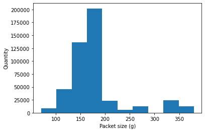

```python
# Minimum packet size is 70g while max is 380g - this is reasonable.
# Plot a histogram to visualise distribution of pack sizes.
plt.hist(trans_df['PACK_SIZE'], weights=trans_df['PROD_QTY']);
plt.xlabel('Packet size (g)');
plt.ylabel('Quantity');
```

```python
# Add a column to extract the first word of each product name to.
trans_df.insert(9, "BRAND_NAME",trans_df['PROD_NAME'].str.split().str.get(0), True)
trans_df
```

|  | DATE | STORE_NBR | LYLTY_CARD_NBR | TXN_ID | PROD_NBR | PROD_NAME | PROD_QTY | TOT_SALES | PACK_SIZE | BRAND_NAME |
| --- | --- | --- | --- | --- | --- | --- | --- | --- | --- | --- |
| 0 | 2018-10-17 | 1 | 1000 | 1 | 5 | Natural Chip Compny SeaSalt175g | 2 | 6.0 | 175.0 | Natural |
| 1 | 2019-05-14 | 1 | 1307 | 348 | 66 | CCs Nacho Cheese 175g | 3 | 6.3 | 175.0 | CCs |
| 2 | 2019-05-20 | 1 | 1343 | 383 | 61 | Smiths Crinkle Cut Chips Chicken 170g | 2 | 2.9 | 170.0 | Smiths |
| 3 | 2018-08-17 | 2 | 2373 | 974 | 69 | Smiths Chip Thinly S/Cream&Onion 175g | 5 | 15.0 | 175.0 | Smiths |
| 4 | 2018-08-18 | 2 | 2426 | 1038 | 108 | Kettle Tortilla ChpsHny&Jlpno Chili 150g | 3 | 13.8 | 150.0 | Kettle |
| ... | ... | ... | ... | ... | ... | ... | ... | ... | ... | ... |
| 264831 | 2019-03-09 | 272 | 272319 | 270088 | 89 | Kettle Sweet Chilli And Sour Cream 175g | 2 | 10.8 | 175.0 | Kettle |
| 264832 | 2018-08-13 | 272 | 272358 | 270154 | 74 | Tostitos Splash Of Lime 175g | 1 | 4.4 | 175.0 | Tostitos |
| 264833 | 2018-11-06 | 272 | 272379 | 270187 | 51 | Doritos Mexicana 170g | 2 | 8.8 | 170.0 | Doritos |
| 264834 | 2018-12-27 | 272 | 272379 | 270188 | 42 | Doritos Corn Chip Mexican Jalapeno 150g | 2 | 7.8 | 150.0 | Doritos |
| 264835 | 2018-09-22 | 272 | 272380 | 270189 | 74 | Tostitos Splash Of Lime 175g | 2 | 8.8 | 175.0 | Tostitos |

246740 rows × 10 columns

```python
# Then print all unique entries to check the brand names created
trans_df["BRAND_NAME"].unique()
```

```
array(['Natural', 'CCs', 'Smiths', 'Kettle', 'Grain', 'Doritos',
       'Twisties', 'WW', 'Thins', 'Burger', 'NCC', 'Cheezels', 'Infzns',
       'Red', 'Pringles', 'Dorito', 'Infuzions', 'Smith', 'GrnWves',
       'Tyrrells', 'Cobs', 'French', 'RRD', 'Tostitos', 'Cheetos',
       'Woolworths', 'Snbts', 'Sunbites'], dtype=object)
```

```python
# Create a function to identify the string replacements needed.
def replace_brandname(line):
    name = line['BRAND_NAME']
    if name == "Infzns":
        return "Infuzions"
    elif name == "Red":
        return "Red Rock Deli"
    elif name == "RRD":
        return "Red Rock Deli"
    elif name == "Grain":
        return "Grain Waves"
    elif name == "GrnWves":
        return "Grain Waves"
    elif name == "Snbts":
        return "Sunbites"
    elif name == "Natural":
        return "Natural Chip Co"
    elif name == "NCC":
        return "Natural Chip Co"
    elif name == "WW":
        return "Woolworths"
    elif name == "Smith":
        return "Smiths"
    elif name == "Dorito":
        return "Doritos"
    else:
         return name

# Then apply the function to clean the brand names
trans_df["BRAND_NAME"] = trans_df.apply(lambda line: replace_brandname(line), axis=1)

# Check that there are no duplicate brands
trans_df["BRAND_NAME"].unique()
```

```
array(['Natural Chip Co', 'CCs', 'Smiths', 'Kettle', 'Grain Waves',
       'Doritos', 'Twisties', 'Woolworths', 'Thins', 'Burger', 'Cheezels',
       'Infuzions', 'Red Rock Deli', 'Pringles', 'Tyrrells', 'Cobs',
       'French', 'Tostitos', 'Cheetos', 'Sunbites'], dtype=object)
```

```python
# Now examine customer data
cust_df = Purchasedata.copy()
cust_df.head()
```

|  | LYLTY_CARD_NBR | LIFESTAGE | PREMIUM_CUSTOMER |
| --- | --- | --- | --- |
| 0 | 1000 | YOUNG SINGLES/COUPLES | Premium |
| 1 | 1002 | YOUNG SINGLES/COUPLES | Mainstream |
| 2 | 1003 | YOUNG FAMILIES | Budget |
| 3 | 1004 | OLDER SINGLES/COUPLES | Mainstream |
| 4 | 1005 | MIDAGE SINGLES/COUPLES | Mainstream |

```python
# Rename "PREMIUM_CUSTOMER" to "MEMBER_TYPE" for easier identification of the column data
cust_df = cust_df.rename(columns={'PREMIUM_CUSTOMER': 'MEMBER_TYPE'})
```

```python
# Check the summary of the customer data
cust_df.describe()
```

|  | LYLTY_CARD_NBR |
| --- | --- |
| count | 7.263700e+04 |
| mean | 1.361859e+05 |
| std | 8.989293e+04 |
| min | 1.000000e+03 |
| 25% | 6.620200e+04 |
| 50% | 1.340400e+05 |
| 75% | 2.033750e+05 |
| max | 2.373711e+06 |

```python
# Check the entries in the member type and lifestage columns
cust_df["MEMBER_TYPE"].unique()
```

```
array(['Premium', 'Mainstream', 'Budget'], dtype=object)
```

```python
cust_df["LIFESTAGE"].unique()
```

```
array(['YOUNG SINGLES/COUPLES', 'YOUNG FAMILIES', 'OLDER SINGLES/COUPLES',
       'MIDAGE SINGLES/COUPLES', 'NEW FAMILIES', 'OLDER FAMILIES',
       'RETIREES'], dtype=object)
```

```python
# Join the customer and transaction datasets, and sort transactons by date
full_df = trans_df.set_index('LYLTY_CARD_NBR').join(cust_df.set_index('LYLTY_CARD_NBR'))
full_df = full_df.reset_index()
full_df = full_df.sort_values(by='DATE').reset_index(drop=True)
full_df
```

|  | LYLTY_CARD_NBR | DATE | STORE_NBR | TXN_ID | PROD_NBR | PROD_NAME | PROD_QTY | TOT_SALES | PACK_SIZE | BRAND_NAME | LIFESTAGE | MEMBER_TYPE |
| --- | --- | --- | --- | --- | --- | --- | --- | --- | --- | --- | --- | --- |
| 0 | 21037 | 2018-07-01 | 21 | 17576 | 62 | Pringles Mystery Flavour 134g | 2 | 7.4 | 134.0 | Pringles | RETIREES | Mainstream |
| 1 | 25040 | 2018-07-01 | 25 | 21704 | 87 | Infuzions BBQ Rib Prawn Crackers 110g | 2 | 7.6 | 110.0 | Infuzions | OLDER FAMILIES | Budget |
| 2 | 59236 | 2018-07-01 | 59 | 55555 | 42 | Doritos Corn Chip Mexican Jalapeno 150g | 2 | 7.8 | 150.0 | Doritos | OLDER SINGLES/COUPLES | Budget |
| 3 | 271083 | 2018-07-01 | 271 | 268688 | 97 | RRD Salt & Vinegar 165g | 2 | 6.0 | 165.0 | Red Rock Deli | YOUNG FAMILIES | Budget |
| 4 | 65015 | 2018-07-01 | 65 | 61737 | 17 | Kettle Sensations BBQ&Maple 150g | 2 | 9.2 | 150.0 | Kettle | YOUNG FAMILIES | Premium |
| ... | ... | ... | ... | ... | ... | ... | ... | ... | ... | ... | ... | ... |
| 246735 | 48160 | 2019-06-30 | 48 | 44051 | 11 | RRD Pc Sea Salt 165g | 2 | 6.0 | 165.0 | Red Rock Deli | RETIREES | Mainstream |
| 246736 | 175371 | 2019-06-30 | 175 | 176890 | 40 | Thins Chips Seasonedchicken 175g | 2 | 6.6 | 175.0 | Thins | OLDER SINGLES/COUPLES | Budget |
| 246737 | 203312 | 2019-06-30 | 203 | 203610 | 68 | Pringles Chicken Salt Crips 134g | 2 | 7.4 | 134.0 | Pringles | MIDAGE SINGLES/COUPLES | Mainstream |
| 246738 | 222003 | 2019-06-30 | 222 | 221524 | 17 | Kettle Sensations BBQ&Maple 150g | 2 | 9.2 | 150.0 | Kettle | RETIREES | Mainstream |
| 246739 | 55142 | 2019-06-30 | 55 | 49322 | 78 | Thins Chips Salt & Vinegar 175g | 2 | 6.6 | 175.0 | Thins | RETIREES | Mainstream |

246740 rows × 12 columns

```python
# Check for nulls in the full dataset
full_df.isnull().values.any()
```

```
False
```

```python
# looks like all the data is reasonable so export to CSV
full_df.to_csv('QVI_fulldata.csv')
```

# Data analysis on customer segments

```python
# calculate total sales by lifestage and member type and generate a list
total_sales_cust = full_df.groupby(['LIFESTAGE','MEMBER_TYPE'], as_index = False)['TOT_SALES'].agg(['sum'])
total_sales_cust = total_sales_cust.rename(columns={'sum': 'sum_tot_sales'})
total_sales_cust.sort_values(by = "sum_tot_sales", ascending = False)
```

| LIFESTAGE | MEMBER_TYPE | sum_tot_sales |
| --- | --- | --- |
| OLDER FAMILIES | Budget | 156863.75 |
| YOUNG SINGLES/COUPLES | Mainstream | 147582.20 |
| RETIREES | Mainstream | 145168.95 |
| YOUNG FAMILIES | Budget | 129717.95 |
| OLDER SINGLES/COUPLES | Budget | 127833.60 |
|  | Mainstream | 124648.50 |
|  | Premium | 123537.55 |
| RETIREES | Budget | 105916.30 |
| OLDER FAMILIES | Mainstream | 96413.55 |
| RETIREES | Premium | 91296.65 |
| YOUNG FAMILIES | Mainstream | 86338.25 |
| MIDAGE SINGLES/COUPLES | Mainstream | 84734.25 |
| YOUNG FAMILIES | Premium | 78571.70 |
| OLDER FAMILIES | Premium | 75242.60 |
| YOUNG SINGLES/COUPLES | Budget | 57122.10 |
| MIDAGE SINGLES/COUPLES | Premium | 54443.85 |
| YOUNG SINGLES/COUPLES | Premium | 39052.30 |
| MIDAGE SINGLES/COUPLES | Budget | 33345.70 |
| NEW FAMILIES | Budget | 20607.45 |
|  | Mainstream | 15979.70 |
|  | Premium | 10760.80 |

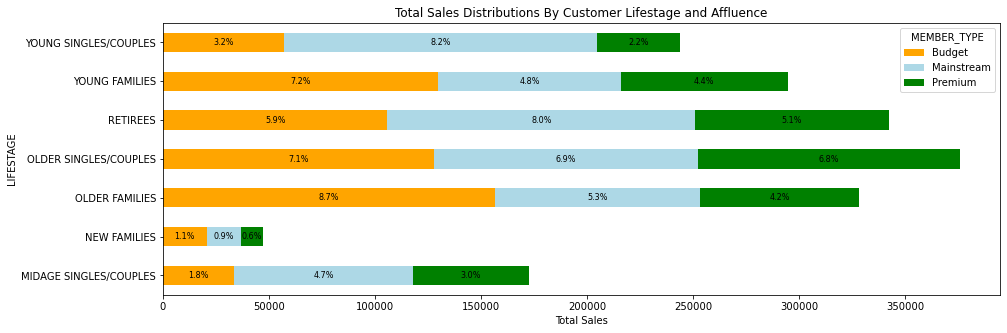

```python
# Get the total sales
total_sales = full_df['TOT_SALES'].agg(['sum'])['sum']

# Plot a breakdown of the total sales by lifestage and member type
total_sales_breakdown = full_df.groupby(['LIFESTAGE','MEMBER_TYPE'], as_index = False)['TOT_SALES'].agg(['sum', 'mean']).unstack('MEMBER_TYPE').fillna(0)
ax = total_sales_breakdown['sum'].plot(kind='barh', stacked=True, figsize=(15, 5),color=['orange','lightblue','green'])

# Add percentages of the summed total sales as labels to each bar
# .patches is everything inside of the chart
for rect in ax.patches:
    # Find where everything is located
    height = rect.get_height()
    width = rect.get_width()
    label = width / total_sales * 100
    x = rect.get_x()
    y = rect.get_y()

    label_text = f'{(label):.1f}%'

    # Set label positions
    label_x = x + width / 2
    label_y = y + height / 2

    # only plot labels greater than given width
    if width > 0:
        ax.text(label_x, label_y, label_text, ha='center', va='center', fontsize=8,)

ax.set_xlabel("Total Sales")
ax.set_title('Total Sales Distributions By Customer Lifestage and Affluence')
plt.show()
```

We can then take a look at the total and average units of chips bought per customer by LIFESTAGE and MEMBER_TYPE.

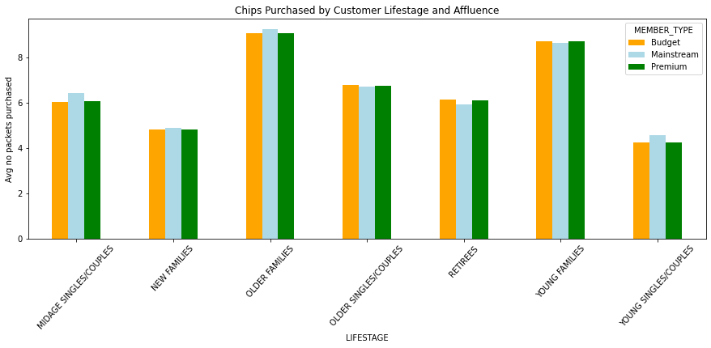

```python
# Get the total bought chips per customer
no_packets_data = full_df.groupby(['LIFESTAGE','MEMBER_TYPE'])['PROD_QTY'].sum()/full_df.groupby(['LIFESTAGE','MEMBER_TYPE'])['LYLTY_CARD_NBR'].nunique(0)
ax = no_packets_data.unstack('MEMBER_TYPE').fillna(0).plot.bar(stacked = False,figsize=(15, 5), color=['orange','lightblue','green'])
ax.set_ylabel("Avg no packets purchased")
ax.set_title('Chips Purchased by Customer Lifestage and Affluence')
plt.xticks(rotation=48)
plt.show()
```

Older families and young families in general buy more chips per customer. We can also investigate the average price per unit sold by LIFESTAGE and MEMBER_TYPE.

```python
# Create a column for the unit price of chips purchased per transaction
full_df['UNIT_PRICE'] = full_df['TOT_SALES']/full_df['PROD_QTY']
```

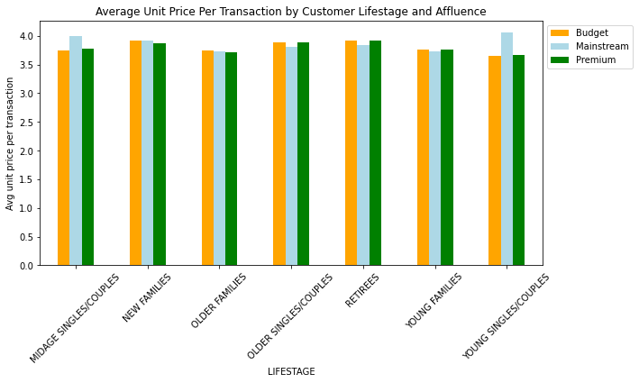

```python
# Plot the distribution of the average unit price per transaction by LIFESTAGE and MEMBER_TYPE.
avg_priceperunit = full_df.groupby(['LIFESTAGE', 'MEMBER_TYPE'], as_index = False)['UNIT_PRICE'].agg(['mean']).unstack('MEMBER_TYPE').fillna(0)
ax = avg_priceperunit['mean'].plot.bar(stacked=False, figsize=(10, 5),  color=['orange','lightblue','green'])
ax.set_ylabel("Avg unit price per transaction")
ax.set_title('Average Unit Price Per Transaction by Customer Lifestage and Affluence')
plt.legend(loc = "upper left",bbox_to_anchor=(1.0, 1.0))
plt.xticks(rotation=45)
plt.show()
```

For young and midage singles/couples, the mainstream group are more willing to pay more for a packet of chips than their budget and premium counterpart. Given the total sales, as well as the number of customers buying chips, is higher in these groups compared to the non-mainstream groups, this suggests that chips may not be the choice of snack for these groups. Further information on shopping habits would be useful in this case.

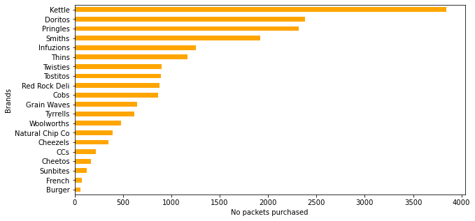

```python
# Create a visual of what brands young singles/couples are purchasing the most for a general indication
young_mainstream = full_df.loc[full_df['LIFESTAGE'] == "YOUNG SINGLES/COUPLES"]
young_mainstream = young_mainstream.loc[young_mainstream['MEMBER_TYPE'] == "Mainstream"]
ax = young_mainstream["BRAND_NAME"].value_counts().sort_values(ascending = True).plot.barh(figsize=(10, 5),color=['orange',])
ax.set_xlabel("No packets purchased")
ax.set_ylabel("Brands")
plt.show()
```

We also want to find out if our target segment tends to buy larger packs of chips.

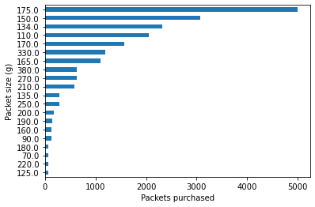

```python
# Plot the distribution of the packet sizes for a general indication of what it most popular.
young_mainstream = full_df.loc[full_df['LIFESTAGE'] == "YOUNG SINGLES/COUPLES"]
young_mainstream = young_mainstream.loc[young_mainstream['MEMBER_TYPE'] == "Mainstream",]
ax = young_mainstream["PACK_SIZE"].value_counts().sort_values(ascending = True).plot.barh()
ax.set_ylabel("Packet size (g)")
ax.set_xlabel("Packets purchased")
plt.show()
```

# Summary of Insights

The three highest contributing segments to the total sales are:

Older families - Budget Young singles/couples - Mainstream Retirees - Mainstream